# Project2_R

##Text Mining Text mining is an technology that performs various operations on unstructured text in documents to generate structure data that can be used for different types of analysis.The purpose is generate structured information, extract meaningful insights from the text which is hidden in the initial stage. Text databases consist of huge collection of documents.The data is collected from several sources such as news articles, books, social medias, digital libraries, web pages etc. Due to increase in the amount, in many of the databases, the data are unstructured or semi-structured. The important goal of text mining is to derive high quality information from the text.Thus, text mining is an artificial intelligence technology that uses natural language processing to perform such transformation to discover new information.The areas of text mining include:- information retrieval, data mining, natural language processing, information extraction.

##Performing text mining in own data #Loading data

```r
#install.packages("tm")
library(tm)
myCorpus <- Corpus(DirSource("AboutNepal")) #AboutNepal is folder that contains .txt file
inspect(myCorpus[[2]])
```

```
## <<PlainTextDocument>>
## Metadata:  7
## Content:  chars: 5157
##
## Nepal contains a disproportionately large diversity of plants and animals, relative to its size.[85][86] Nepal, in its entirety, forms the western portion of the eastern Himalayan biodiversity hotspot, with notable biocultural diversity.[87] The dramatic differences in elevation found in Nepal (6…
##
## Nepal's forest cover is 59,624 km2 (23,021 sq mi), 40.36% of the country's total land area, with an additional 4.38% of scrubland, for a total forested area of 44.74%, an increase of 5% since the turn of the millennium.[89] The country had a 2019 Forest Landscape Integrity Index mean score of 7.2…
##
##
## The greater one-horned rhinoceros roams the sub-tropical grasslands of the Terai plains.
## Among the notable trees, are the astringent Azadirachta indica, or neem, which is widely used in traditional herbal medicine,[92] and the luxuriant Ficus religiosa, or peepal,[93] which is displayed on the ancient seals of Mohenjo-daro,[94] and under which Gautam Buddha is recorded in the Pali ca…
##
## Most of the subtropical evergreen broad-leaved forest of the lower Himalayan region is descended from the Tethyan Tertiary flora.[96] As the Indian Plate collided with Eurasia forming and raising the Himalayas, the arid and semi-arid Mediterranean flora was pushed up and adapted to the more alpin…
##
##
## The Himalayan monal (Danphe), the national bird of Nepal,[100] nests high in the Himalayas.
## Nepal contains 107 IUCN-designated threatened species, 88 of them animal species, 18 plant species and one species of "fungi or protist" group.[101] These include the endangered Bengal tiger, the red panda, the Asiatic elephant, the Himalayan musk deer, the wild water buffalo and the South Asian …
```

```r
(n <- length(myCorpus))
```

```
## [1] 10
```

#Converting the whole text to lower case

```r
myCorpus <- tm_map(myCorpus,tolower)
inspect(myCorpus[[2]])
```

```
## <<PlainTextDocument>>
## Metadata:  7
## Content:  chars: 5157
##
## nepal contains a disproportionately large diversity of plants and animals, relative to its size.[85][86] nepal, in its entirety, forms the western portion of the eastern himalayan biodiversity hotspot, with notable biocultural diversity.[87] the dramatic differences in elevation found in nepal (6…
##
## nepal's forest cover is 59,624 km2 (23,021 sq mi), 40.36% of the country's total land area, with an additional 4.38% of scrubland, for a total forested area of 44.74%, an increase of 5% since the turn of the millennium.[89] the country had a 2019 forest landscape integrity index mean score of 7.2…
##
##
## the greater one-horned rhinoceros roams the sub-tropical grasslands of the terai plains.
## among the notable trees, are the astringent azadirachta indica, or neem, which is widely used in traditional herbal medicine,[92] and the luxuriant ficus religiosa, or peepal,[93] which is displayed on the ancient seals of mohenjo-daro,[94] and under which gautam buddha is recorded in the pali ca…
##
## most of the subtropical evergreen broad-leaved forest of the lower himalayan region is descended from the tethyan tertiary flora.[96] as the indian plate collided with eurasia forming and raising the himalayas, the arid and semi-arid mediterranean flora was pushed up and adapted to the more alpin…
##
##
## the himalayan monal (danphe), the national bird of nepal,[100] nests high in the himalayas.
## nepal contains 107 iucn-designated threatened species, 88 of them animal species, 18 plant species and one species of "fungi or protist" group.[101] these include the endangered bengal tiger, the red panda, the asiatic elephant, the himalayan musk deer, the wild water buffalo and the south asian …
```

#Removing Punctuation

```r
myCorpus <- tm_map(myCorpus,removePunctuation)
inspect(myCorpus[[2]])
```

```
## <<PlainTextDocument>>
## Metadata:  7
## Content:  chars: 4898
##
## nepal contains a disproportionately large diversity of plants and animals relative to its size8586 nepal in its entirety forms the western portion of the eastern himalayan biodiversity hotspot with notable biocultural diversity87 the dramatic differences in elevation found in nepal 60 m from sea …
##
## nepals forest cover is 59624 km2 23021 sq mi 4036 of the countrys total land area with an additional 438 of scrubland for a total forested area of 4474 an increase of 5 since the turn of the millennium89 the country had a 2019 forest landscape integrity index mean score of 72310 ranking it 45th g…
##
##
## the greater onehorned rhinoceros roams the subtropical grasslands of the terai plains
## among the notable trees are the astringent azadirachta indica or neem which is widely used in traditional herbal medicine92 and the luxuriant ficus religiosa or peepal93 which is displayed on the ancient seals of mohenjodaro94 and under which gautam buddha is recorded in the pali canon to have so…
##
## most of the subtropical evergreen broadleaved forest of the lower himalayan region is descended from the tethyan tertiary flora96 as the indian plate collided with eurasia forming and raising the himalayas the arid and semiarid mediterranean flora was pushed up and adapted to the more alpine clim…
##
##
## the himalayan monal danphe the national bird of nepal100 nests high in the himalayas
## nepal contains 107 iucndesignated threatened species 88 of them animal species 18 plant species and one species of fungi or protist group101 these include the endangered bengal tiger the red panda the asiatic elephant the himalayan musk deer the wild water buffalo and the south asian river dolphi…
```

#Removing Numbers

```r
myCorpus <- tm_map(myCorpus,removeNumbers)
inspect(myCorpus[[2]])
```

```
## <<PlainTextDocument>>
## Metadata:  7
## Content:  chars: 4667
##
## nepal contains a disproportionately large diversity of plants and animals relative to its size nepal in its entirety forms the western portion of the eastern himalayan biodiversity hotspot with notable biocultural diversity the dramatic differences in elevation found in nepal  m from sea level in…
##
## nepals forest cover is  km  sq mi  of the countrys total land area with an additional  of scrubland for a total forested area of  an increase of  since the turn of the millennium the country had a  forest landscape integrity index mean score of  ranking it th globally out of  countries in the sou…
##
##
## the greater onehorned rhinoceros roams the subtropical grasslands of the terai plains
## among the notable trees are the astringent azadirachta indica or neem which is widely used in traditional herbal medicine and the luxuriant ficus religiosa or peepal which is displayed on the ancient seals of mohenjodaro and under which gautam buddha is recorded in the pali canon to have sought e…
##
## most of the subtropical evergreen broadleaved forest of the lower himalayan region is descended from the tethyan tertiary flora as the indian plate collided with eurasia forming and raising the himalayas the arid and semiarid mediterranean flora was pushed up and adapted to the more alpine climat…
##
##
## the himalayan monal danphe the national bird of nepal nests high in the himalayas
## nepal contains  iucndesignated threatened species  of them animal species  plant species and one species of fungi or protist group these include the endangered bengal tiger the red panda the asiatic elephant the himalayan musk deer the wild water buffalo and the south asian river dolphin as well …
```

#Removing stopwords of the english language

```r
myCorpus <- tm_map(myCorpus,removeWords,stopwords("english"))
inspect(myCorpus[[2]])
```

```
## <<PlainTextDocument>>
## Metadata:  7
## Content:  chars: 3932
##
## nepal contains  disproportionately large diversity  plants  animals relative   size nepal   entirety forms  western portion   eastern himalayan biodiversity hotspot  notable biocultural diversity  dramatic differences  elevation found  nepal  m  sea level   terai plains   m mount everest result  …
##
## nepals forest cover   km  sq mi    countrys total land area   additional   scrubland   total forested area    increase   since  turn   millennium  country    forest landscape integrity index mean score   ranking  th globally    countries   southern plains teraiâ€“duar savanna  grasslands ecoregio…
##
##
##  greater onehorned rhinoceros roams  subtropical grasslands   terai plains
## among  notable trees   astringent azadirachta indica  neem   widely used  traditional herbal medicine   luxuriant ficus religiosa  peepal   displayed   ancient seals  mohenjodaro    gautam buddha  recorded   pali canon   sought enlightenment
##
##    subtropical evergreen broadleaved forest   lower himalayan region  descended   tethyan tertiary flora   indian plate collided  eurasia forming  raising  himalayas  arid  semiarid mediterranean flora  pushed   adapted    alpine climate   next â€“ million years  himalayan biodiversity hotspot   …
##
##
##  himalayan monal danphe  national bird  nepal nests high   himalayas
## nepal contains  iucndesignated threatened species    animal species  plant species  one species  fungi  protist group  include  endangered bengal tiger  red panda  asiatic elephant  himalayan musk deer  wild water buffalo   south asian river dolphin  well   critically endangered gharial  bengal f…
```

#Removing whitespaces

```r
myCorpus <- tm_map(myCorpus,stripWhitespace)
inspect(myCorpus[[2]])
```

```
## <<PlainTextDocument>>
## Metadata:  7
## Content:  chars: 3612
##
## nepal contains disproportionately large diversity plants animals relative size nepal entirety forms western portion eastern himalayan biodiversity hotspot notable biocultural diversity dramatic differences elevation found nepal m sea level terai plains m mount everest result variety biomes easter…
```

#Performing Lemmatization

```r
#install.packages("textstem")
library(textstem)
myCorpus <- tm_map(myCorpus,lemmatize_strings)
inspect(myCorpus[[2]])
```

```
## <<PlainTextDocument>>
## Metadata:  7
## Content:  chars: 3453
##
## nepal contain disproportionately large diversity plant animal relative size nepal entirety form western portion eastern himalayan biodiversity hotspot notable biocultural diversity dramatic difference elevation find nepal be sea level terai plain be mount everest result variety biome eastern half…
```

#Preparing Document Matrix

```r
myTdm <- TermDocumentMatrix(myCorpus,control=list(wordLengths=c(1,Inf)))
(freq.terms <- findFreqTerms(myTdm,lowfreq=20))
```

```
##  [1] "also"        "century"     "country"     "form"        "high"
##  [6] "include"     "india"       "indian"      "kathmandu"   "language"
## [11] "late"        "nepal"       "nepali"      "party"       "province"
## [16] "region"      "south"       "th"          "traditional" "valley"
## [21] "world"       "among"       "area"        "good"        "national"
## [26] "nepals"      "one"         "population"  "terai"       "year"
## [31] "around"      "main"        "make"        "many"        "people"
## [36] "rate"        "wear"        "government"
```

#Viewing the corelations between the words.

```r
findAssocs(myTdm,"nepal",0.8)
```

```
## $nepal
##     peaceful     majority    president          new         join          map
##         0.92         0.89         0.89         0.88         0.86         0.86
## constitution        leave    political    neighbour  cooperation      capital
##         0.85         0.85         0.85         0.84         0.84         0.82
##       system  independent       policy     assembly       commit      defence
##         0.82         0.82         0.82         0.82         0.82         0.82
##       direct      dispute     division independence     internal     mahendra
##         0.82         0.82         0.82         0.82         0.82         0.82
##   neutrality    overthrow    personnel      politic   revolution        yadav
##         0.82         0.82         0.82         0.82         0.82         0.82
##          arm        right    executive       leader          one
##         0.81         0.81         0.81         0.81         0.80
```

```r
findAssocs(myTdm,"country",0.8)
```

```
## $country
##         cross    government             s         major      province
##          0.95          0.92          0.91          0.89          0.87
##      cultural     committee      ministry   recognition       require
##          0.87          0.87          0.87          0.87          0.87
##        search sudurpashchim      progress        affair       citizen
##          0.87          0.87          0.86          0.85          0.85
##         enter     essential          free       gandaki       general
##          0.85          0.85          0.85          0.85          0.85
##      initiate      janakpur    management      minority significantly
##          0.85          0.85          0.85          0.85          0.85
##         enjoy         index   cooperation
##          0.84          0.83          0.81
```

#Generating Word Clouds

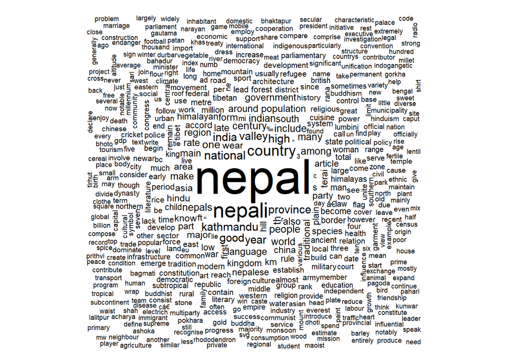

```r
#install.packages("wordcloud")
library(wordcloud)
m <- as.matrix(myTdm)
freq <- sort(rowSums(m),decreasing = T)
wordcloud(words=names(freq),freq=freq,min.freq=4,random.order = F)
```

#Performing topic modelling

```r
#install.packages("topicmodels")
library(topicmodels)
set.seed(123)
myLda <- LDA(as.DocumentTermMatrix(myTdm),k=8)
terms(myLda,5)
```

```
##      Topic 1   Topic 2       Topic 3     Topic 4    Topic 5  Topic 6 Topic 7
## [1,] "nepal"   "nepali"      "nepal"     "nepal"    "ne"     "ft"    "nepal"
## [2,] "country" "nepal"       "century"   "species"  "nepal"  "metre" "man"
## [3,] "nepals"  "wear"        "th"        "country"  "accord" "nepal" "nepali"
## [4,] "sector"  "national"    "kathmandu" "forest"   "valley" "zone"  "many"
## [5,] "high"    "traditional" "kingdom"   "province" "mean"   "plain" "woman"
##      Topic 8
## [1,] "nepal"
## [2,] "province"
## [3,] "nepali"
## [4,] "party"
## [5,] "country"
```

#Viewing the processed text data in plots.

[figure not shown]

```r
myTdm2 <- removeSparseTerms(myTdm,sparse = 0.95)
m2 <-as.matrix(myTdm2)
distMatrix <-dist(scale(m2))
fit <- hclust(distMatrix,method="ward.D")
plot(fit)
```